# Chopped

```r
# Getting the data
chop <- readr::read_tsv('https://raw.githubusercontent.com/rfordatascience/tidytuesday/master/data/2020/2020-08-25/chopped.tsv')
```

# Introduction

This week’s data comes from the show ‘Chopped’. The data dictionary:

| variable | class | description |
| --- | --- | --- |
| season | double | Season Number |
| season_episode | double | Episode number within a season |
| series_episode | double | Episode number as part of the entire series |
| episode_rating | double | IMDB sourced episode rating 0-10 scale |
| episode_name | character | Episode Name |
| episode_notes | character | Episode notes |
| air_date | character | Episode air date |
| judge1 | character | Judge 1 Name |
| judge2 | character | Judge 2 Name |
| judge3 | character | Judge 3 Name |
| appetizer | character | Appetizer ingredients |
| entree | character | Entree ingredients |
| dessert | character | Dessert ingredients |
| contestant1 | character | Contestant 1 name |
| contestant1_info | character | Contestant 1 Info |
| contestant2 | character | Contestant 2 name |
| contestant2_info | character | Contestant 2 Info |
| contestant3 | character | Contestant 3 name |
| contestant3_info | character | Contestant 3 Info |
| contestant4 | character | Contestant 4 name |
| contestant4_info | character | Contestant 4 Info |

A quick skim:

```r
chop %>%
  skimr::skim()
```

```
-- Data Summary ------------------------
                           Values
Name                       Piped data
Number of rows             569
Number of columns          21
_______________________
Column type frequency:
  character                17
  numeric                  4
________________________
Group variables            None

-- Variable type: character -------------------------------------------
# A tibble: 17 x 8
   skim_variable    n_missing complete_rate   min   max empty n_unique
 * <chr>                <int>         <dbl> <int> <int> <int>    <int>
 1 episode_name             0         1         6    77     0      568
 2 episode_notes          113         0.801    12   830     0      455
 3 air_date                 0         1        11    18     0      564
 4 judge1                   1         0.998     9    18     0       37
 5 judge2                   1         0.998     9    18     0       27
 6 judge3                   1         0.998     6    19     0       95
 7 appetizer                1         0.998    18   135     0      568
 8 entree                   1         0.998    34   126     0      568
 9 dessert                  1         0.998    28   117     0      568
10 contestant1              1         0.998     6    45     0      566
11 contestant1_info        13         0.977     2   114     0      502
12 contestant2              1         0.998     7    48     0      561
13 contestant2_info        14         0.975     2   119     0      510
14 contestant3              1         0.998     6    53     0      556
15 contestant3_info        14         0.975     2   120     0      505
16 contestant4              1         0.998     8    45     0      507
17 contestant4_info        14         0.975     2   140     0      494
   whitespace
 *      <int>
 1          0
 2          0
 3          0
 4          0
 5          0
```

[output cut: 12 more lines]

```

-- Variable type: numeric ---------------------------------------------
# A tibble: 4 x 11
  skim_variable  n_missing complete_rate   mean      sd    p0   p25
* <chr>              <int>         <dbl>  <dbl>   <dbl> <dbl> <dbl>
1 season                 0         1      23.1   13.0     1    12
2 season_episode         0         1       7.02   3.98    1     4
3 series_episode         0         1     285.   164.      1   143
4 episode_rating       105         0.815   8.38   0.477   5.5   8.2
    p50   p75  p100 hist
* <dbl> <dbl> <dbl> <chr>
1  23    35    45   ▇▇▇▇▇
2   7    10    20   ▇▇▇▂▁
3 285   427   567   ▇▇▇▇▇
4   8.5   8.7   9.2 ▁▁▂▅▇
```

# Analysis

I would like to parse the ingredients to make a list of ingredients by meal. Do the show makers prefer certain ingredients? Do the judges prefer certain ingredients? Let’s work on that. I bet that’s going to be a common direction, but it at least gives me some text work to do.

Georgios Karamanis’s graphic for this week is interesting: it shows the cut injuries in Chopped over time. First, how have there been 45 seasons? Second, do cutting injuries (or other types of injuries) correlate with ratings? Are there other things that contribute to ratings? Do ratings vary much? Let’s look.

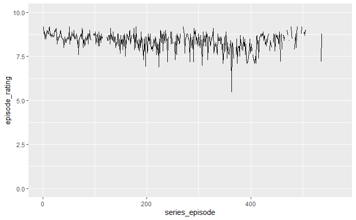

```r
chop %>%
  ggplot() +
  geom_line(aes(x = series_episode, y = episode_rating)) +
  scale_y_continuous(limits = c(0,10))
```

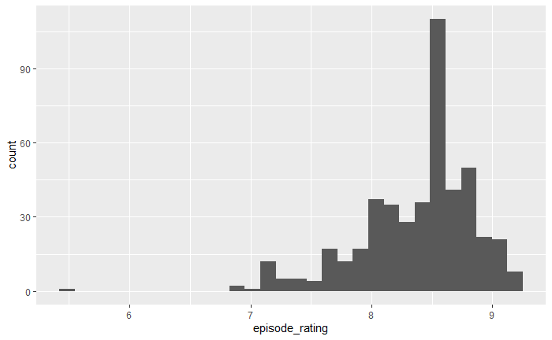

```r
chop %>%
  ggplot() +
  geom_histogram(aes(episode_rating))
```

At the moment, I’m on a different tack. I’m reading the episode descriptions for potential things to mine. So far, the descriptions are mostly related to eliminations. I guess one could look at female vs. male eliminations with some basic natural language processing. I’m not that excited by that one, though. Sometimes, they have episodes called “Chopped Champions”. Maybe these are better rated?

| is_champions | mean_rating | median_rating | n |
| --- | --- | --- | --- |
| FALSE | 8.377243 | 8.5 | 558 |
| TRUE | 8.828571 | 8.9 | 11 |

Shows:

- Worst Cooks in America
- Iron Chef
- Beat Bobby Flay
- Guy’s Grocery Games

Other things that might boost ratings include celebrities (how common?), number of words in the description as a proxy for number of interesting things that happened in that episode.

First, let’s look at crossovers:

| crossover | is_crossover | mean_rating | median_rating | n |
| --- | --- | --- | --- | --- |
| bbf | FALSE | 8.381602 | 8.50 | 567 |
| bbf | TRUE | 8.950000 | 8.95 | 2 |
| ggg | FALSE | 8.383766 | 8.50 | 567 |
| ggg | TRUE | 8.450000 | 8.45 | 2 |
| ic | FALSE | 8.381917 | 8.50 | 562 |
| ic | TRUE | 8.580000 | 8.60 | 7 |
| wcia | FALSE | 8.389827 | 8.50 | 567 |
| wcia | TRUE | 7.050000 | 7.05 | 2 |

That was a failure. I must have seen the only crossovers there in the first few episodes, because there are only a dozen. Next up is celebrities.

| has_celebrity | mean_rating | median_rating | n |
| --- | --- | --- | --- |
| FALSE | 8.391574 | 8.5 | 550 |
| TRUE | 8.123077 | 8.4 | 19 |

Again, not very many examples of this. Effectively no difference in ratings regardless. Let’s just look at cuttings, because I know that data exists and I need to feel better.

```r
chop %>%
  mutate(is_cut = grepl("\\bcut", episode_notes)) %>%
  tabyl(is_cut)
```

```
 is_cut   n    percent
  FALSE 523 0.91915641
   TRUE  46 0.08084359
```

So, in fact, there are not many episodes with cuts either. This is actually reflected in Georgio’s graphic, I just wasn’t paying close attention. So, that makes me feel somewhat better about the numbers I was getting. Okay, let’s now assume that more words in the description means a greater number of events, and see whether a greater number of events is associated with higher ratings.

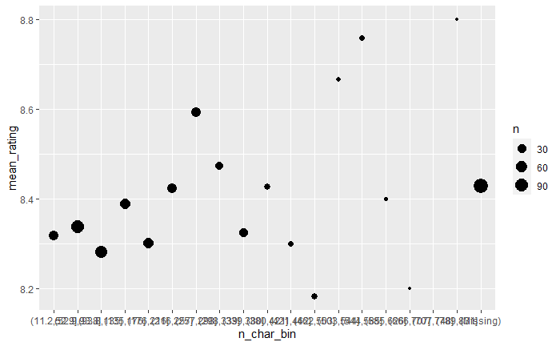

I think there is a slight upward trend here, especially at the low end of the scale. Of course, the high end of the scale gets a bit fuzzy, but that’s a sample size problem most likely. The graphic just isn’t very interesting, I think.

What else? I’m getting tired of the ratings idea – I would rather move towards trends, the evidence of other textual clues. What else do I have? Ingredients, but those probably don’t recur often enough. Names, which aren’t very useful without some sort of name library or something.

I may have an answer. The worst rated episode of the show was the episode “Worst Cooks Challenge”, number 363. I can see the headline: Worst cooks, worst episodes.

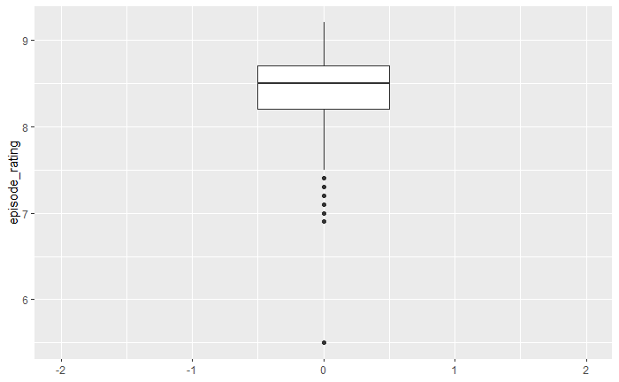

Something like that could be interesting. But it’s not a whole visualization. It doesn’t present very much data – it’s a single data point that’s kind of funny. I need a data story.

There are no particularly highly rated episodes. Could you make the argument that the people who rate the show are snobs? If they don’t like bad chefs, maybe the top-rated episodes have a pattern as well. Worth a shot, anyway.

| season | season_episode | series_episode | episode_rating | episode_name | episode_notes | air_date | judge1 | judge2 | judge3 | appetizer | entree | dessert | contestant1 | contestant1_info | contestant2 | contestant2_info | contestant3 | contestant3_info | contestant4 | contestant4_info |
| --- | --- | --- | --- | --- | --- | --- | --- | --- | --- | --- | --- | --- | --- | --- | --- | --- | --- | --- | --- | --- |
| 1 | 1 | 1 | 9.2 | Octopus, Duck, Animal Crackers | This is the first episode with only three official ingredients in a basket (dessert round). There would be no hard set limit until season 4. | January 13, 2009 | Marc Murphy | Alex Guarnaschelli | Aarón Sánchez | baby octopus, bok choy, oyster sauce, smoked paprika | duck breast, green onions, ginger, honey | prunes, animal crackers, cream cheese | Summer Kriegshauser | Private Chef and Nutrition Coach New York NY | Perry Pollaci | Private Chef and Sous chef Bar Blanc New York NY | Katie Rosenhouse | Pastry Chef Olana Restaurant New York NY | Sandy Davis | Catering Chef Showstoppers Catering at Union Theological Seminary New York NY |
| 1 | 13 | 13 | 9.2 | Strawberries, Turkey and Gummi Bears | NA | April 7, 2009 | Scott Conant | Amanda Freitag | Aarón Sánchez | salmon, radicchio, ginger, strawberries | turkey breast, baby turnips, pearl onions, coconut flakes | blackberries, kiwi, wonton wrappers, gummy bears | Victor Cabezas | Chef and Owner Misaví Totowa NJ | Jonathan Contes | Chef and Part Owner Eat Mosaic St. James Long Island NY | Amy Roth | Chef and Owner Amy Kate Catering New York NY | Michael Carrino | Chef and Owner Restaurant Passionné Montclair NJ |
| 4 | 12 | 51 | 9.2 | Crunch Time | This was the first appearance of Madison Cowan, who would go on to appear on various Food Network shows as a contestant and a judge including Iron Chef America, Beat Bobby Flay, and Guy's Grocery Game… | July 6, 2010 | Scott Conant | Amanda Freitag | Marc Murphy | watermelon, sweet potatoes, knockwurst, almond butter | skate, English cucumbers, prunes, shredded wheat crackers | oranges, red miso paste, cottage cheese, kettle-cooked potato chips | Steven Tempel | Chef and Restaurateur Logan's Bar and Grill Speculator NY | Michele Ragussis | Chef and Restaurateur Stuft Catering / Beast Brooklyn NY | Lance Nitahara | Executive Chef Camp-of-the-Woods Speculator NY | Madison Cowan | Chef and Caterer Avenue Inc New York NY |
| 15 | 6 | 179 | 9.2 | Amazing Amateurs | This was an official amateurs episode which was preceded by an unofficial amateurs episode (Momumental). The contestants wore regular clothes during the competition but winner Marisa Biaggi received a… | May 14, 2013 | Geoffrey Zakarian | Alex Guarnaschelli | Aarón Sánchez | dragon fruit, guanciale, sunflower sprouts, scallops | pork chops, yacon, broccoli rabe, burgundy truffles | honey soaked nuts, organic red wine, calamansi limes, salted butter crackers | Nate Echelberger | Pastor of Gateway Church in Austin TX | Melissa Campbell | Training Administrator from Los Angeles CA | Rique Uresti | Spin Instructor from New York NY | Marisa Biaggi | Content Producer and Strategist/PR from New York NY |
| 22 | 6 | 270 | 9.2 | Bizarre Baskets | Judge Andrew Zimmern is the host of several programs on the Travel Channel featuring "bizarre" foods. All baskets featured a series of highly unusual ingredients. Chef Peterson works at Beauty & Essex… | January 20, 2015 | Andrew Zimmern | Aarón Sanchez | Geoffrey Zakarian | lox ice cream, wasabi microgreens, pink asparagus, ground camel | kholodets, flaming shiso, blue foot mushrooms, goat head | unlaid chicken eggs, sour cream, rambutan, Turkish tavuk gogsu | Nico Romo | Culinary Director & French Master Chef from Charleston SC | Geoff Rhyne | Chef de Cuisine from Charleston SC | Aaron Barnett | Chef & Restaurateur from Portland OR | Timothy Peterson | Sous Chef from New York NY |
| 38 | 8 | 478 | 9.2 | Nourish and Flourish | The theme of this episode was "good food that's good for you", meaning lighter and healthier ingredients in every basket and every dish. | January 8, 2019 | Scott Conant | Alex Guarnaschelli | Seamus Mullen | sardines, Jew's mallow, bone broth, turmeric ice cream | radicchio, savory oatmeal, beef tenderloin, chocolate with chili | blueberries, walnuts in the shell, white bean cookie dough dip, ginger tonic | Danielle Ennesser-Quirino | Chef & Owner from Scottsdale AZ | Lex Grant | Private Chef & Owner from Newark NJ | Jacob Pitts | Executive Sous Chef from Manassas VA | Jermain Edwards | Executive Chef from New York NY |
| 39 | 6 | 489 | 9.2 | Dollar Dishes | The theme of this episode was "budget baskets" with every round having low-cost ingredients. | March 26, 2019 | Scott Conant | Alex Guarnaschelli | Tiffani Faison | frozen taquitos, dozen eggs, frozen corn, home grown basil | beef tripe stew, chicken legs, broccoli, instant mashed potatoes | blueberry muffin mix, cream cheese, carrots, white wine ice cubes | Stephan Brezinsky | Chef and Owner from New York NY | Allen Fisher | Executive Sous Chef from Woodstock NY | Sebastian Wijata | Chef from Scottsdale AZ | Figgy DiBenedetto | Chef and Owner from Portland ME |
| 40 | 2 | 498 | 9.2 | Whiz Kid Cooks | The contestants were all children. Instead of the usual 20 minutes, the first round was extended to 30 minutes. In the third round, the kids were given miniature gumball machines filled with candy, an… | September 4, 2018 | Marc Murphy | Amanda Freitag | Geoffrey Zakarian | ground chicken, rapini, lemon sorbet, tahini paste | flat iron steak, sprouting cauliflower, waffle fries, dates | Linzer cookies, baby kiwis, cherry kombucha, candy dispenser | Ryan Greenberg | age 12 from Livingston NJ | Django Santalis | age 10 from Patterson NY | Pipa Hardin | age 12 from Campbell CA | Rachel Goldzal | age 12 from Staten Island NY |

How should I process this? Pull each, concatenate into a single string (sep comma), split by comma.

```r
foods <- tibble(
  app = foods[[1]][[1]],
  entree = foods[[2]][[1]],
  dessert = foods[[3]][[1]]
)
```

```
Error: Tibble columns must have compatible sizes.
* Size 2239: Existing data.
* Size 2281: Column `entree`.
i Only values of size one are recycled.
```

```r
(n_duplicated <- c(
  app = length(app[duplicated(app)]),
  entree = length(entree[duplicated(entree)]),
  dessert = length(dessert[duplicated(dessert)])
))
```

```
    app  entree dessert
    538     615     616
```

A surprising number of ingredients have been repeated. How many times does each ingredient get used? Which are the most popular? This might not be as clean in base R as it is in the Tidyverse. I guess I could convert them quickly and then use `janitor::tabyl()`.

[output not shown]

```r
tibble(app = app) %>%
  tabyl(app) %>%
  arrange(desc(n)) %>%
  head(n = 10)


tibble(entree = entree) %>%
  tabyl(entree) %>%
  arrange(desc(n)) %>%
  head(n = 10)
```

|  | entree | n | percent |
| --- | --- | --- | --- |
| 1 | okra | 12 | 0.005260851 |
| 2 | rainbow chard | 11 | 0.004822446 |
| 3 | broccoli rabe | 10 | 0.004384042 |
| 4 | quail | 9 | 0.003945638 |
| 5 | bok choy | 8 | 0.003507234 |
| 6 | goat chops | 8 | 0.003507234 |
| 7 | rainbow carrots | 8 | 0.003507234 |
| 8 | artichokes | 7 | 0.003068829 |
| 9 | Brussels sprouts | 7 | 0.003068829 |
| 10 | duck breast | 7 | 0.003068829 |

```r
tibble(dessert = dessert) %>%
  tabyl(dessert) %>%
  arrange(desc(n)) %>%
  head(n = 10)
```

|  | dessert | n | percent |
| --- | --- | --- | --- |
| 1 | blackberries | 13 | 0.005731922 |
| 2 | blueberries | 10 | 0.004409171 |
| 3 | figs | 10 | 0.004409171 |
| 4 | cream cheese | 9 | 0.003968254 |
| 5 | marshmallow spread | 9 | 0.003968254 |
| 6 | peaches | 9 | 0.003968254 |
| 7 | rambutan | 9 | 0.003968254 |
| 8 | strawberries | 9 | 0.003968254 |
| 9 | bananas | 8 | 0.003527337 |
| 10 | blood oranges | 8 | 0.003527337 |

Now that’s more like it. Graphic: show how many unique ingredients there are for each meal, followed by the top 5 ingredients by number of times eaten. I’ll finish the thing tomorrow, but I want basic versions of the data tonight.